# The Study of Wine Quality - Part B

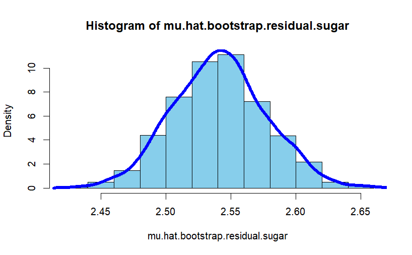

```r
hist(mu.hat.bootstrap.residual.sugar,col = "skyblue", freq = FALSE)
lines(density(mu.hat.bootstrap.residual.sugar), lwd=5, col='blue')
```

```r
NA
NA
```

```r
library(magrittr)
library(dplyr)
Excellent_Wine<- Red_Wine_Data %>%
  mutate(excellent = (Red_Wine_Data$quality >=7))


sample_mean_quality<- mean(Excellent_Wine$excellent)
cat("Sample mean of quality is:",sample_mean_quality,"\n")
```

```
Sample mean of quality is: 0.1357098
```

```r
sd_clt_quality= sd(Excellent_Wine$excellent) / sqrt(n)
cat("Standard deviation of Quality using CLt",sd_clt_quality,"\n")
```

```
Standard deviation of Quality using CLt 0.00856736
```

```r
lower_end_quality<- sprintf("%.5f",sample_mean_quality-(sd_clt_quality*2))
upper_end_quality<- sprintf("%.5f",sample_mean_quality+(sd_clt_quality*2))


# Print the formatted confidence interval
cat("95% Confidence Interval for μ of quality (using CLT):",lower_end_quality, ",", upper_end_quality, "\n")
```

```
95% Confidence Interval for μ of quality (using CLT): 0.11858 , 0.15284
```

2. **Use the bootstrap method to derive a 95% confidence interval for p;**

```r
# Initialize an empty vector to store bootstrap sample means
mu.hat.bootstrap.quality <- numeric(2000)

# Perform bootstrapping
for (k in 1:2000) {
  sample.bootstrap.quality <- sample(Excellent_Wine$excellent, size = 1599, replace = TRUE)
  mu.hat.bootstrap.quality[k] <- mean(sample.bootstrap.quality)
}

# Calculate the standard deviation of mu.hat.bootstrap
sd_bootstrap_quality <- sd(mu.hat.bootstrap.quality)

# Print the standard deviation obtained from bootstrapping
cat("Standard Deviation of mu.hat.bootstrap for 'quality':", sd_bootstrap_quality, "\n")
```

```
Standard Deviation of mu.hat.bootstrap for 'quality': 0.008560782
```

```r
# Calculate the 95% bootstrap confidence interval for mu using quantile
bootstrap_ci_quality <- quantile(mu.hat.bootstrap.quality, c(0.025, 0.975))

# Print the bootstrap confidence interval
cat("95% Bootstrap Confidence Interval for 'quality':", bootstrap_ci_quality[1], ",", bootstrap_ci_quality[2], "\n")
```

```
95% Bootstrap Confidence Interval for 'quality': 0.1188243 , 0.1525954
```

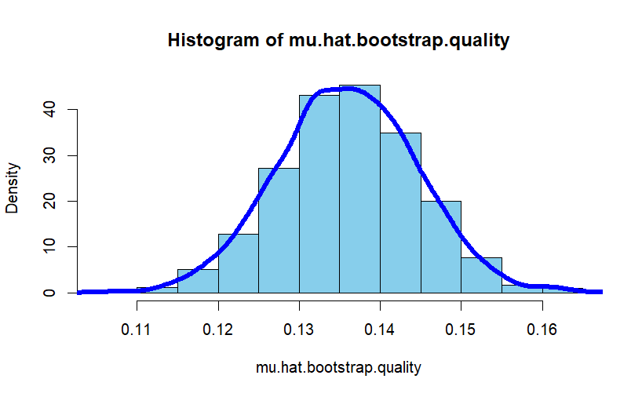

```r
hist(mu.hat.bootstrap.quality,col = "skyblue", freq = FALSE)
lines(density(mu.hat.bootstrap.quality), lwd=5, col='blue')
```

3. **Compare the two intervals. Is there any difference worth our attention?**
- 95% Confidence Interval for μ of quality (using CLT): 0.11858 , 0.15284. We can also infer this as 11.85% and 15.28% as lower and upper values of the dataset.
- 95% Bootstrap Confidence Interval for ‘quality’: 0.1188243 , 0.1525954
- Both the intervals are once again similar to each other, because of which there is no significant attention-worthy characteristic. Both intervals provide consistent and reliable estimates, and the choice between these methods is unlikely to have a substantial impact on the conclusions drawn from the data.
- Roughly, we can say that 13.565% of the data population are of excellent quality.

Note: you need to create a new column of data for the new variable “excellent” which has binary values (0 and 1). Its value is 1 if the wine rating >=7, and otherwise its value is 0. Then, you can make inference about the underlying proportion parameter p